# Reproducing Numerical Results in Python from "Some New Results on the Maximum Growth Factor in Gaussian Elimination" by Alan Edelman and John Urschel

The paper referenced can be found [here](https://math.mit.edu/~urschel/preprints/gauss.pdf). This post aims reproduce the numerical results from the non-linear optimization model shown in Figure 2 in the paper by the means of a slightly different formulation in Python. It is recommended to read through the paper, but a short description of what the below model is given.

In the context of Gaussian Elimination, we consider $n \times n$ non-singular matrices $A$ that under the complete pivoting strategy require no pivots for each elimination step. In other words, $|a_{ijk}| \leq |a_{kkk}|\; \forall k \in {1,...,n},\; i,j \geq k$, where $a_{ijk}=$ the element in $A$ where $i$ and $j$ are the row and column index respectively, and $k$ is the index of the elimination step.

The goal is to find an $A$ such that the growth factor $g(A)$ of Gaussian Elimination is maximized, where $g(A) = \frac{\text{max}_{ijk}|a_{ijk}|}{\text{max}_{ij}|a_{ij1}|}$. In other words, the ratio of the absolute value of all elements seen in each elimination step over the max absolute value in the original matrix. This ratio gives a sense of how large the values in the matrix can grow during the elimination process, which is key to the numerical stability of solving large systems.

The optimization model below is motivated by the Julia code presented in the paper in Figure 3. The model defines each element for each elimination step as the decision variables. For simplicity, the first element is restricted to be 1 to normalize the matrix as this does not impact the optimial result of the ratio given the linear relationship of Gaussian Elimination. The remaining constraints enforce the requirements of $A$ as described above. Since the elimination step is not linear, ie $x_{i,j,k+1} = x_{i,j,k} - \frac{x_{i,k,k}}{x_{k,k,k}}x_{k,j,k}$, a non-linear solver is required. We use [Ipopt](https://coin-or.github.io/Ipopt/) as do the authors. We also provide the solver an initial solution that satisfies the contraints on $A$.

```python
import numpy as np
from pyomo.environ import *
import matplotlib.pyplot as plt
```

The below function creates an $n \times n$ matrix that is diagonally dominated with randomness to satisfy the constraints on $A$.

```python
def create_no_pivot_matrix(n):
    A = np.random.rand(n, n)
    max_row_sum = np.max(np.sum(A, axis = 1))
    np.fill_diagonal(A, np.sort(max_row_sum + np.random.rand(n)*np.arange(n))[::-1])
    return A
```

The below function calls the above function and performs complete pivoting Guassian Elimination and returns the 3D matrix that holds all the values of $A$ for each elimination step.

```python
def complete_pivoting(n):
    A_orig = create_no_pivot_matrix(n).astype(float)
    n = A_orig.shape[0]
    A = np.copy(A_orig).astype(float)

    Ak = []
    max_k = -float("inf")
    for k in range(n-1):
        Ak.append(np.copy(A))

        # find index of max value in subarray
        A_sub = A[k:, k:]
        max_ind = np.unravel_index(np.argmax(A_sub), A_sub.shape)
        max_ind = (max_ind[0] + k, max_ind[1] + k)

        # swap row and column
        A[[k, max_ind[0]], :] = A[[max_ind[0], k], :]
        A[:, [k, max_ind[1]]] = A[:, [max_ind[1], k]]

        # eliminate
        for i in range(k+1, n):
            A[i, :] += -A[i, k] / A[k, k] * A[k, :]

        # update max
        max_k_temp = np.max(A)
        if max_k_temp > max_k:
            max_k = max_k_temp

    Ak.append(np.copy(A))
    Ak = np.array(Ak)
    max_gf = max_k / np.max(A_orig).astype(float)
    return Ak, max_gf
```

The below function formulates the optimization model using Pyomo as described above. The comments are meant to guide the user each aspect of the model.

```python
def run_model(n):
    # MODEL SETUP
    startmatrix = complete_pivoting(n)[0]
    startmatrix /= startmatrix[0,0,0] # normalize
    model = ConcreteModel()
    model.S = RangeSet(0, n-1)
    model.x = Var(model.S, model.S, model.S, initialize=lambda model, i, j, k: startmatrix[k, i, j])

    # CONSTRAINTS
    # zero eliminated indices
    model.con0 = ConstraintList()
    for k in range(1, n):
        for j in range(k):
            for i in range(j+1, n):
                model.con0.add(expr = model.x[i,j,k] == 0)

    # normalize first element
    model.con1 = Constraint(expr = model.x[0,0,0] == 1)

    # non-negative first element for each sub-array
    model.con2 = ConstraintList()
    for k in range(n):
        model.con2.add(expr = model.x[k,k,k] >= 0)

    # original array bounded/normalized between -1 and 1
    model.con3 = ConstraintList()
    for i in range(n):
        for j in range(n):
            model.con3.add(expr = model.x[i,j,0] >= -1)
            model.con3.add(expr = model.x[i,j,0] <= 1)

    # retain the property for completely pivoted matrix
    model.con4 = ConstraintList()
    for k in range(1, n-1):
        for i in range(k, n):
            for j in range(k, n):
                model.con4.add(expr = model.x[i,j,k] <= model.x[k,k,k])
                model.con4.add(expr = model.x[i,j,k] >= -model.x[k,k,k])

    # define elimination steps
    model.con5 = ConstraintList()
    for k in range(n-1):
        for i in range(k+1, n):
            for j in range(k+1, n):
                model.con5.add(expr = model.x[i,j,k+1] == model.x[i,j,k] - (model.x[i,k,k]/model.x[k,k,k])*model.x[k,j,k])
    # OBJECTIVE
    model.obj = Objective(expr = model.x[n-1,n-1,n-1], sense = maximize)
    lp_file = "model.nl"
    model.write(lp_file, io_options={"symbolic_solver_labels": True})

    # SOLVE
    solver = SolverFactory('ipopt')
    solver.options['max_iter'] = 10_000

    solver.solve(model)
    #print(f"Objective value for n = {n}, {round(value(model.obj),4)}")
    return round(value(model.obj),4)
```

The below code is the driver that runs the optimization model and plots the results to compare to Figure 2 in the paper. The model is run over all $n \in {1,...,N}$, and repeated $T$ times with each different initial solutions to keep track of the best solution. While the paper runs their model over $n \in \{1,...,75\} \cup \{100\}$ and $T = 64$, the below more restricted values with less compute resources show that the results closely convey the similar conculsions and numerical results as the authors present in the paper.

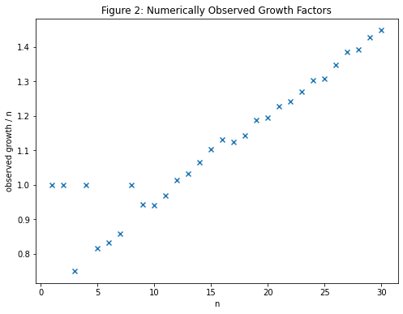

```python
N = 30
T = 5
objs = np.zeros(N)

for _ in range(T):
    for n in range(1, N+1):
        res = run_model(n)/n
        if res > objs[n-1]:
            objs[n-1] = res

plt.figure(figsize=(8, 6))
plt.scatter(range(1, N+1), objs, marker = "x")
plt.xlabel('n')
plt.ylabel('observed growth / n')
plt.title('Figure 2: Numerically Observed Growth Factors')
plt.show()
```